# Non-perturbation methods

useR! 2024

Jiří Novák

8.7.2024

# 1 Introduction

This notebook is dedicated to non-perturbation methods. We will start with the basics and then move to more advanced methods.

Non-perturbation masking are methods that alter data to hide identities without changing its actual value. It does not rely on distortion of the original data but on partial suppressions or reductions of detail.

This includes methods such as: **Sampling**, **Global recoding**, **Top and bottom coding**, **Local suppression**, **Table redesign**.

# 2 Little bit of methodology

## 2.1 Methods

- **Sampling** - Selecting a subset of the data to be released.
- **Global recoding** - Re-categorisation applied to the data to reduce the level of detail.
  - Example: Employment size-classes 250-499, 500- 999 1000+ are merged into a single class, 250+
- **Top and bottom coding** - All values above or below a specified value are set to that value, or to a code indicating the class.
  - Example: All turnovers over €500 000 are set to equal €500 000 or to 500+.
- **Local suppression** - Suppressing individual cells in a table to prevent disclosure of sensitive information.
- **Table redesign** - Collapsing rows and/or columns of a table to reduce the level of detail in the data.

## 2.2 Identification

We distinguish between *direct* and *indirect* identification of a statistical unit

- **direct identification** means identification on the basis of name, address or other identification number,
  - i.e. on the basis of any identifier that can be used without the need to spend disproportionate time and effort to establish the identity of the person in question
- **indirect identification** means identification in a way other than direct identification

Direct identification is prevented by removing variables containing this sensitive data. This is considered the **first step in the process of statistical dislosure methods**.

The effort is therefore to prevent **indirect identification**, which can occur, for example, by adding up the search values, or by using an external dataset or auxiliary information.

We further may divide protection into **primary** and **secondary** confidentiality protection in case of *tabular* data, whose dissemination would permit attribute disclosure.

- **Primary confidentiality** is the protection of the individual cells of the table.
  - Refers to data whose aggregate value could allow for the identification of an individual unit.
  - There are two main reasons to declare data as primarily confidential:
    - **Too Few Units in a Cell**
      - If there are too few units in a cell, the data in that cell may be considered confidential.
      - A cell in a frequency table is defined as sensitive if the number of respondents is less than a specified number.
      - Tested using the threshold rule (minimum number rule), which is based on the frequency of units in a cell.
      - generaly, 3 and more units in a cell are considered safe.
    - **Dominance of One or Several Units in a Cell**
      - If one or a few units dominate a cell, the data in that cell may be considered confidential.
      - Tested using the (n,k) dominance rule or p%-rule.
      - Only make sense if the size of the variable is ‘identifying’! i.e., if ‘intruders’ know who the largest respondents are.
      - (n,k) dominance rule: A cell is unsafe, if the largest *n* contributions in that cell amount to more than *k* % of the cell total.
        - For example, if n = 2 and k = 70, it means that the cell is defined as confidential if the two largest units contribute more than 70% to the total.
      - p%-rule: A cell is unsafe if some respondent to that cell can estimate another respondent to that cell within p % of its true value.
        - For example, if p = 5, it means that the cell is defined as confidential if the value of one unit can be estimated within 5% of its true value.
- **Secondary confidentiality** is the protection of the table as a whole.
  - This is important because it can be used to identify individuals by combining information from different cells.
  - Refers to table data that is not primarily confidential, but whose value, in combination with other data, allows for the identification of primarily protected units.
  - The most common method is **cell suppression**.
    - The goal is to prevent the disclosure of sensitive information by suppressing certain cells in the table.
    - The suppression of a cell means that the value of the cell is not published in the table.

### 2.2.1 Secondary confidentiality example

Illustrative example table representing Dividends paid by large national company

| **Sex/Age** | **0-30** | **31-50** | **51-65** | **66-80** | **81+** | **Total** |
| --- | --- | --- | --- | --- | --- | --- |
| **Males** | **2** | **170** | 400 | 930 | **70** | 1572 |
| **Females** | **8** | **350** | 179 | 621 | **300** | 1458 |
| **Total** | 10 | 520 | 579 | 1551 | 370 | 3030 |

Red - primary protection because in the given the group suppose it has only one such recipient of dividends.

Orange - primary protection because share of the largest recipient of dividends exceeds 70%

Green shading – secondary protection, additionally suppressed aggregates so that the primary protected cannot be estimated with great accuracy.

## 2.3 Variables

It is important to distinguish different types of variables: **direct identifiers**, **indirect identifiers** and **key variables**

**Direct identifiers**

- such as name or unique identification number.
- always removed from the microdata files, as they are clearly disclosive.

**Indirect identifiers**

- such as NACE category, size class or region – which divide the total population into subpopulations;
- may be disclosive in combination with other variables.
- The variables most likely to lead to identification are called *quasi-identifiers*.

**Key variables**

- represent the criterion by which the confidentiality flag is set for variables.
- This variables must be protected.

## 2.4 Important!

**Confidentiality protection always precedes dissemination when deciding whether to release potentially confidential information.**

# 3 Let’s try it out!

## 3.1 Table redesign

**Task:** Combine rows and/or columns to increase the number of units that fall into cells.

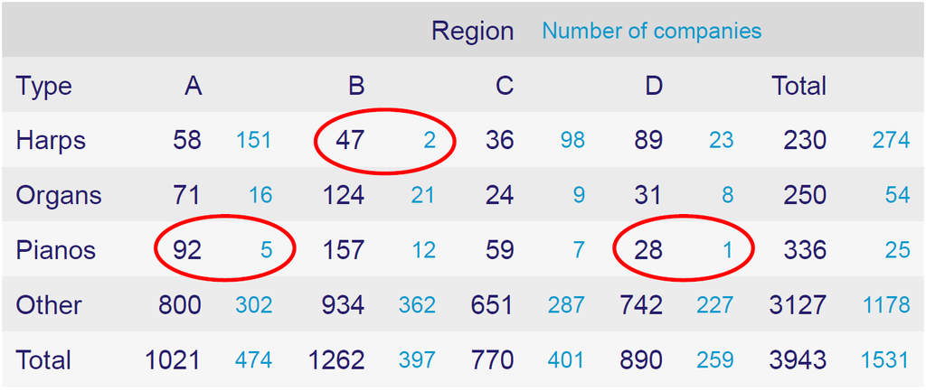

Figure: Number of products and companies in regions

## 3.2 Sampling

This approach is based on the idea that the risk of disclosure is reduced by releasing only a subset of the data. Example can be seen for example in the [UK Census data](https://www.ons.gov.uk/census/aboutcensus/censusproducts/microdatasamples), where the data is released in the form of a sample.

- *Microdata samples range in size from 10% to 1% of households or individuals.*

## 3.3 Example

We will use functions from the package *sdcMicro*

```r
library(sdcMicro)
```

### 3.3.1 Data

We will use the SILC data (Statistics on Income and Living Conditions) from Austria. This is a synthetic data set based on Austrian EU-SILC data from 2006. The data set consists of 6 000 households.

```r
library(laeken)
data(eusilc)
data <- eusilc
```

Let’s have a look at the data.

```r
head(eusilc)
```

|  | db030 | hsize | db040 | rb030 | age | rb090 | pl030 | pb220a | py010n | py050n | py090n | py100n | py110n | py120n | py130n | py140n | hy040n | hy050n | hy070n | hy080n | hy090n | hy110n | hy130n | hy145n | eqSS | eqIncome | db090 | rb050 |
| --- | --- | --- | --- | --- | --- | --- | --- | --- | --- | --- | --- | --- | --- | --- | --- | --- | --- | --- | --- | --- | --- | --- | --- | --- | --- | --- | --- | --- |
| 1 | 1 | 3 | Tyrol | 101 | 34 | female | 2 | AT | 9756.25 | 0 | 0 | 0 | 0 | 0 | 0 | 0 | 4273.9 | 2428.11 | 0 | 0 | 33.39 | 0 | 0 | 0 | 1.8 | 16090.69 | 504.5696 | 504.5696 |
| 2 | 1 | 3 | Tyrol | 102 | 39 | male | 1 | Other | 12471.60 | 0 | 0 | 0 | 0 | 0 | 0 | 0 | 4273.9 | 2428.11 | 0 | 0 | 33.39 | 0 | 0 | 0 | 1.8 | 16090.69 | 504.5696 | 504.5696 |
| 3 | 1 | 3 | Tyrol | 103 | 2 | male | NA | NA | NA | NA | NA | NA | NA | NA | NA | NA | 4273.9 | 2428.11 | 0 | 0 | 33.39 | 0 | 0 | 0 | 1.8 | 16090.69 | 504.5696 | 504.5696 |
| 4 | 2 | 4 | Tyrol | 201 | 38 | female | 7 | AT | 12487.03 | 0 | 0 | 0 | 0 | 0 | 0 | 0 | 0.0 | 1549.72 | 0 | 0 | 2.13 | 0 | 0 | 0 | 2.1 | 27076.24 | 493.3824 | 493.3824 |
| 5 | 2 | 4 | Tyrol | 202 | 43 | male | 1 | AT | 42821.23 | 0 | 0 | 0 | 0 | 0 | 0 | 0 | 0.0 | 1549.72 | 0 | 0 | 2.13 | 0 | 0 | 0 | 2.1 | 27076.24 | 493.3824 | 493.3824 |
| 6 | 2 | 4 | Tyrol | 203 | 11 | male | NA | NA | NA | NA | NA | NA | NA | NA | NA | NA | 0.0 | 1549.72 | 0 | 0 | 2.13 | 0 | 0 | 0 | 2.1 | 27076.24 | 493.3824 | 493.3824 |

Only a few of the large number of variables in the original survey are included in this example data set. The variable names are rather cryptic codes, but these are the standardized names used by the statistical agencies. Furthermore, the variables hsize, age, eqSS and eqIncome are not included in the standardized format of EU-SILC data, but have been derived from other variables for convenience.

### 3.3.2 Variables

We have a data frame with 14 827 observations on the following 28 variables:

- **db030** integer; the household ID.
- **hsize** integer; the number of persons in the household.
- **db040** factor; the federal state in which the household is located (levels Burgenland, Carinthia, Lower Austria, Salzburg, Styria, Tyrol, Upper Austria, Vienna and Vorarlberg).
- **rb030** integer; the personal ID. age integer; the person’s age.
- **rb090** factor; the person’s gender (levels male and female).
- **pl030** factor; the person’s economic status (levels 1 = working full time, 2 = working part time, 3 = unemployed, 4 = pupil, student, further training or unpaid work experience or in compulsory military or community service, 5 = in retirement or early retirement or has given up business, 6 =permanently disabled or/and unfit to work or other inactive person, 7 = fulfilling domestic tasks and care responsibilities).
- **pb220a** factor; the person’s citizenship (levels AT, EU and Other).
- **py010n** numeric; employee cash or near cash income (net).
- **py050n** numeric; cash benefits or losses from self-employment (net).
- **py090n** numeric; unemployment benefits (net).
- **py100n** numeric; old-age benefits (net).
- **py110n** numeric; survivor’s benefits (net).
- **py120n** numeric; sickness benefits (net).
- **py130n** numeric; disability benefits (net).
- **py140n** numeric; education-related allowances (net).
- **hy040n** numeric; income from rental of a property or land (net).
- **hy050n** numeric; family/children related allowances (net).
- **hy070n** numeric; housing allowances (net).
- **hy080n** numeric; regular inter-household cash transfer received (net).
- **hy090n** numeric; interest, dividends, profit from capital investments in unincorporated business (net).
- **hy110n** numeric; income received by people aged under 16 (net).
- **hy130n** numeric; regular inter-household cash transfer paid (net).
- **hy145n** numeric; repayments/receipts for tax adjustment (net).
- **eqSS** numeric; the equivalized household size according to the modified OECD scale.
- **eqIncome** numeric; a slightly simplified version of the equivalized household income.
- **db090** numeric; the household sample weights.
- **rb050** numeric; the personal sample weights.

### 3.3.3 Selecting key variables

The sdcMicro package is built around objects of class sdcMicroObj. Now we need to select our key variables and sample weights. After exploring the data and developing disclosure risk scenarios, we identified the following key variables:

```r
# categorical key variables
KeyVars <- c('age',
             'rb090',
             'db040',
             'hsize',
             'pb220a'
)
# sample weights
Weights <- c('rb050')
```

### 3.3.4 Create subset of the data file

Now that we know the keys variables that we want to focus on we are going to create a subset of the data file that contains only these variables and our sample weights.

```r
## Create Subset of Data File
subVars <- c(KeyVars,
             Weights)
subData <- data[,subVars]
```

### 3.3.5 Create sdcmicro object

Finally, you are ready to create the sdcMicro object. Use the arguments of the function createSdcObj() to specify the data file (subData), the sample weights (Weights) and the key variables (KeyVars, NumVars).

```r
## Create sdcMicro object
objSDC <- createSdcObj(dat = subData,
                       keyVars = KeyVars,
                       weightVar = Weights)
```

### 3.3.6 Calculate individual risk, sample and population frequency

With key variables selected and sdcMicro object created, we are ready to run the assessment. First, we are going to create a new data frame that will combine the sample frequency (fk), population frequency (Fk) and individual risk measures to the subset of the data file that we created.

```r
individual_risk <- objSDC@risk$individual
indRisk_table <- cbind(subData,individual_risk)
indRisk_table
```

|  | age | rb090 | db040 | hsize | pb220a | rb050 | risk | fk | Fk |
| --- | --- | --- | --- | --- | --- | --- | --- | --- | --- |
| 1 | 34 | female | Tyrol | 3 | AT | 504.5696 | 1.961280e-03 | 2 | 1009.1392 |
| 2 | 39 | male | Tyrol | 3 | Other | 504.5696 | 1.235918e-02 | 1 | 504.5696 |
| 3 | 2 | male | Tyrol | 3 | NA | 504.5696 | 4.952264e-04 | 5 | 2522.8481 |
| 4 | 38 | female | Tyrol | 4 | AT | 493.3824 | 3.376902e-04 | 7 | 3453.6765 |
| 5 | 43 | male | Tyrol | 4 | AT | 493.3824 | 1.558854e-04 | 14 | 6907.3529 |
| 6 | 11 | male | Tyrol | 4 | NA | 493.3824 | 5.064498e-04 | 5 | 2466.9118 |
| 7 | 9 | male | Tyrol | 4 | NA | 493.3824 | 4.052009e-04 | 6 | 2960.2941 |
| 8 | 26 | female | Vienna | 1 | AT | 868.2204 | 1.144112e-03 | 2 | 1736.4408 |
| 9 | 47 | male | Vienna | 5 | Other | 635.4571 | 1.017302e-02 | 1 | 635.4571 |
| 10 | 28 | male | Vienna | 5 | AT | 635.4571 | 5.242817e-04 | 4 | 2541.8286 |

[output cut: 990 more lines]

**Individual Risk**: The calculated individual risk values indicate how likely it is that a particular individual’s data could be identified. Lower values mean lower risk of identification.

**Sample Frequency (fk)**: This value shows how many records in the sample have the same combination of key variables. Higher fk values generally imply lower individual risk.

**Population Frequency (Fk):** This value estimates how many records in the population have the same combination of key variables. It helps to understand the rarity of a combination in the broader population.

### 3.3.7 k-anonymity

Next step is to review k-anonymity. Here, we will simply print 2-. 3-, and 5- anonymity.

```r
## print K-anonymity
print(objSDC, type="kAnon")
```

```
Infos on 2/3-Anonymity:

Number of observations violating
  - 2-anonymity: 2042 (13.772%)
  - 3-anonymity: 4256 (28.704%)
  - 5-anonymity: 8190 (55.237%)

----------------------------------------------------------------------
```

As you can see, we have 2042 records that violate 2-anonymity. It is recommend that no record violates 3-anonymity. From here, it’s clear that we will need to apply statistical disclosure control before sharing this data publicly but before we do, we should review the global disclosure risk.

### 3.3.8 Calculate global risk

```r
## Print global risk
print(objSDC, "risk")
```

```
Risk measures:

Number of observations with higher risk than the main part of the data: 0
Expected number of re-identifications: 33.14 (0.22 %)
```

Global risk measures the overall risk of disclosure for the entire dataset.

### 3.3.9 Global recoding

Technique that involves reducing the number of values a given variable can take. It is an effective method for reducing the detail in the data while maintaining some of its analytical power.

```r
## Recode Age Variable
table(objSDC@manipKeyVars$age)
```

```
 -1   0   1   2   3   4   5   6   7   8   9  10  11  12  13  14
 64 153 123 143 166 123 174 164 151 131 197 150 197 198 189 176
 15  16  17  18  19  20  21  22  23  24  25  26  27  28  29  30
221 183 212 160 177 216 195 181 195 180 187 139 168 151 222 181
 31  32  33  34  35  36  37  38  39  40  41  42  43  44  45  46
197 216 223 195 235 224 225 254 237 240 247 277 276 245 268 236
 47  48  49  50  51  52  53  54  55  56  57  58  59  60  61  62
211 216 256 200 180 195 176 188 188 179 201 162 128 128 179 148
 63  64  65  66  67  68  69  70  71  72  73  74  75  76  77  78
153 156 187 179 122 142 120 107 113 114 138 108 136  79  79  77
 79  80  81  82  83  84  85  86  87  88  89  90  91  92  93  94
 93  53  88  75  56  68  53  35  25  11  15  12  17  10   2   1
 95  96  97
  2   3   1
```

```r
objSDC <- globalRecode(objSDC,
                       column = c('age'),
                       breaks = 10 * c(0:10))
table(objSDC@manipKeyVars$age)
```

```
  (0,10]  (10,20]  (20,30]  (30,40]  (40,50]  (50,60]  (60,70]
    1522     1929     1799     2246     2432     1725     1493
 (70,80]  (80,90] (90,100]
     990      438       36
```

```r
# print K-anonymity
print(objSDC, type="kAnon")
```

```
Infos on 2/3-Anonymity:

Number of observations violating
  - 2-anonymity: 195 (1.315%) | in original data: 2042 (13.772%)
  - 3-anonymity: 478 (3.224%) | in original data: 4256 (28.704%)
  - 5-anonymity: 998 (6.731%) | in original data: 8190 (55.237%)

----------------------------------------------------------------------
```

### 3.3.10 Top and bottom coding

All values above or below a specified value are set to that value, or to a code indicating the class.

```r
## Top and Bottom Coding
table(objSDC@manipKeyVars$hsize)
```

```
   1    2    3    4    5    6    7    8    9
1745 3624 3147 3508 1815  630  252   88   18
```

```r
objSDC <- topBotCoding(objSDC,
                       column = c('hsize'),
                       value = 6,
                       replacement = 6,
                       kind = "top")
table(objSDC@manipKeyVars$hsize)
```

```
   1    2    3    4    5    6
1745 3624 3147 3508 1815  988
```

```r
# print K-anonymity
print(objSDC, type="kAnon")
```

```
Infos on 2/3-Anonymity:

Number of observations violating
  - 2-anonymity: 145 (0.978%) | in original data: 2042 (13.772%)
  - 3-anonymity: 335 (2.259%) | in original data: 4256 (28.704%)
  - 5-anonymity: 707 (4.768%) | in original data: 8190 (55.237%)

----------------------------------------------------------------------
```

Let’s assess risk after applying sdc methods.

```r
print (objSDC,"risk")
```

```
Risk measures:

Number of observations with higher risk than the main part of the data:
  in modified data: 0
  in original data: 0
Expected number of re-identifications:
  in modified data: 3.59 (0.02 %)
  in original data: 33.14 (0.22 %)
```

### 3.3.11 Local suppression

Suppressing individual cells in a table to prevent disclosure of sensitive information.

```r
## Create sdcMicro object
objSDC <- createSdcObj(dat = subData,
                       keyVars = KeyVars,
                       weightVar = Weights)
```

```r
objSDC <- localSuppression(objSDC,
                           k = 3,
                           importance = NULL)
calcRisks(objSDC)
```

```
The input dataset consists of 14827 rows and 6 variables.
  --> Categorical key variables: age, rb090, db040, hsize, pb220a
  --> Weight variable: rb050
----------------------------------------------------------------------


Information on categorical key variables:

Reported is the number, mean size and size of the smallest category >0 for recoded variables.
In parenthesis, the same statistics are shown for the unmodified data.
Note: NA (missings) are counted as seperate categories!
```

| Key Variable | Number of categories |  | Mean size |  | Size of smallest (>0) |  |
| --- | --- | --- | --- | --- | --- | --- |
| age | 94 | (99) | 114.032 | (149.768) | 4 | (1) |
| rb090 | 2 | (2) | 7413.500 | (7413.500) | 7267 | (7267) |
| db040 | 9 | (9) | 1647.444 | (1647.444) | 549 | (549) |
| hsize | 10 | (9) | 1642.667 | (1647.444) | 13 | (18) |
| pb220a | 4 | (4) | 4035.667 | (4035.667) | 283 | (283) |

```
----------------------------------------------------------------------


Infos on 2/3-Anonymity:

Number of observations violating
  - 2-anonymity: 0 (0.000%) | in original data: 2042 (13.772%)
  - 3-anonymity: 0 (0.000%) | in original data: 4256 (28.704%)
  - 5-anonymity: 39 (0.263%) | in original data: 8190 (55.237%)

----------------------------------------------------------------------


Local suppression:
```

| KeyVar | \| | Suppressions (#) | \| | Suppressions (%) |
| --- | --- | --- | --- | --- |
| age | \| | 4222 | \| | 28.475 |
| rb090 | \| | 0 | \| | 0.000 |
| db040 | \| | 0 | \| | 0.000 |
| hsize | \| | 43 | \| | 0.290 |
| pb220a | \| | 0 | \| | 0.000 |

## 3.4 Exercise

Now try this on different but same data

```r
# Load the data
library(simPop)
data("eusilc13puf")
```